# Proyecto

Luis Felipe Cubero Vargas & Josue Arrieta

3/9/2020

```r
setwd('~/BI/proy')
```

# 1 Entendimiento del negocio

## 1.1 Objetivos del negocio

Objetivos:

- Determinar que variables predicen la probabilidad de obtener una pieza defectuosa por fallos de ingenieria, con el fin determinar la efectividad de los trabajos de departamento para asi evaluar la asignacion de personal.

Criterio de éxito:

- Predecir que varibles me indican cuando va a suceder una falla en la pieza por fallos de ingenieria.

## 1.2 Evaluación de la situación actual

Inventario de recursos

Como parte de la implementacion de mejora continua en la empresa “Herrero y sobrino”, se cuenta con un departamento de recoleccion de datos en linea que alimenta el inventario de unidades desechadas y sus causas. La empresa igualmente cuenta, con un sistema de ERP que alimienta los datos via cierre y ejecusion de ordenes de produccion, con acceso a los expertos de cada area. Como parte de la implementacion de reduccion de desechos de componentes caros, el departamento de ingenieria esta centralizando los datos en una nube para el analisis del departamento de mejora continua.

Requirimientos

- Acceso informacion de produccion: orden de trabajo, numero de componente, numero dispositivo final, linea, turno y cantidad de desecho.

Supuestos

- Los datos son filtrados por los expertos del area.
- se contabilizan los desechos totales de la pruduccion.

Restricciones

- La empresa cuenta con un sistema de acceso restrigido a la informacion, la data obtenida es una muestra significativa de las mediciones de enero.
- Se cuenta con acceso directo a los datos.

Riesgos y contigencia

Dentro de los riesgos existe la posibilidad de que no encontramos un modelo que pueda ayudarnos a determinar los elementos que predicen en mayor medida la generación de piezas defectuosas.

Por otro lado existe la posibilidad de que ocurra overfitting o underfitting y se realicen prediciones errones que lleven a malas decisiones de negocio, por ejemplo si el modelo determina que el turno es una variable importante y se toman medidas entorno a esta podriamos caer en decisiones no solo que perjudiquen a la empresa si no también a los empleados de la empresa.

Beneficios

- Analisis y provenir el desecho debido a errores de validacion ejecutados por el departamento de ingenieria. ## Plan del Proyecto

Plan del proyecto:

| Fase | Tiempo estimado | Recursos | Riesgos |
| --- | --- | --- | --- |
| Recoleccion de datos | 1 mes | Pesonal de la empresa | -Datos errados -Confidencialidad de la empresa, PN sensibles. |
| Filtro y generacion de base datos | 2 Semanas | Ingenieros de produccion | - Disponibilidad del ingeniero a cargo - Problemas de conexión con la intranet de la empresa. - Capacidad computacional insuficiente. |
| Analisis de base de datos | 3 semanas | Ingenieros de Data Science | - No tener suficientes datos para que el modelo converja - No tener la capacidad de hardware para procesar los datos |
| Conclusion e implementacioon | 1 semana | Stakeholder de la empresa e Ingenieros de Data Science | - Falta de comunicacion. |

Evaluación inicial de herramientas y técnicas

- Postgresql
- Python
- R

## 1.3 Objetivos de minería de datos

El objetivo de la minería de datos es determinar un modelo que me permita obtener los elementos que me explican la generación de piezas defectuosas por problemas de ingenieria.

El criterio de exito es determinar un modelo que me permita predecir en que casos hay probabilidad de que sea una pieza defectuosa debida a fallos de ingenieria en produccion normal.

# 2 Entendimiento de los datos

## 2.1 Recopilación inicial de datos

### 2.1.1 Descripción de los datos

Los datos para el análsis corresponde a una base de datos de un proceso elaboración dispositivos medicos. Donde cada columna esta dado por:

- Production Family: Familia de productos
- Wk: Semana
- Fecha: Fecha
- P/N: Numero de parte del producto
- P/N COMPONENTE: Numero de parte del componente que fallo
- WO: Orden de trabajo
- Quantity: Cantidad de piezas defectuosas
- Cod. Defecto: Codigo de defecto
- Causa
- Linea
- Turno: T1 (Mañana), T 1 (Mañana extendidad), T2 (Tarde),T 2 (Tarde extendido) , T3 (Noche)

### 2.1.2 Exploración de los datos

Lo primero es cargar los datos

```r
datos<- read.csv('scrap_data_final.csv',sep = ';',stringsAsFactors = FALSE)
head(datos)
```

```
##   production_family      wk    fecha fa_pn pn_componente      wo quantity
## 1     Wands (Kamuk) Week 01 1/3/2020 48400         48404 2046690        1
## 2     Wands (Kamuk) Week 01 1/3/2020 48400         48414 2046690        1
## 3     Wands (Kamuk) Week 01 1/3/2020 48400         48416 2046690        1
## 4     Wands (Kamuk) Week 01 1/3/2020 48400         49697 2046690        4
## 5     Wands (Kamuk) Week 01 1/3/2020 48400         20363 2046690        4
## 6     Wands (Kamuk) Week 01 1/3/2020 48400         20363 2046690       10
##   cod_defecto label   linea turno
## 1       D1093     1 Line 13    T1
## 2       DO085     1 Line 13   T 1
## 3      DO1646     1 Line 13   T 1
## 4      DO1644     1 Line 13   T 1
## 5                 0 Line 13   T 1
## 6                 0 Line 13   T 1
```

Ahora reviso la estructura

```r
str(datos)
```

```
## 'data.frame':    19927 obs. of  11 variables:
##  $ production_family: chr  "Wands (Kamuk)" "Wands (Kamuk)" "Wands (Kamuk)" "Wands (Kamuk)" ...
##  $ wk               : chr  "Week 01" "Week 01" "Week 01" "Week 01" ...
##  $ fecha            : chr  "1/3/2020" "1/3/2020" "1/3/2020" "1/3/2020" ...
##  $ fa_pn            : chr  "48400" "48400" "48400" "48400" ...
##  $ pn_componente    : chr  "48404" "48414" "48416" "49697" ...
##  $ wo               : num  2046690 2046690 2046690 2046690 2046690 ...
##  $ quantity         : int  1 1 1 4 4 10 4 6 4 1 ...
##  $ cod_defecto      : chr  "D1093" "DO085" "DO1646" "DO1644" ...
##  $ label            : int  1 1 1 1 0 0 0 1 1 0 ...
##  $ linea            : chr  "Line 13" "Line 13" "Line 13" "Line 13" ...
##  $ turno            : chr  "T1" "T 1" "T 1" "T 1" ...
```

Luego vemos la estadistica descriptiva de los elementos

```r
summary(datos)
```

```
##  production_family       wk               fecha              fa_pn
##  Length:19927       Length:19927       Length:19927       Length:19927
##  Class :character   Class :character   Class :character   Class :character
##  Mode  :character   Mode  :character   Mode  :character   Mode  :character
##
##
##
##
##  pn_componente            wo              quantity        cod_defecto
##  Length:19927       Min.   :  204660   Min.   :    1.00   Length:19927
##  Class :character   1st Qu.: 2046922   1st Qu.:    2.00   Class :character
##  Mode  :character   Median : 2047315   Median :    5.00   Mode  :character
##                     Mean   : 2065848   Mean   :   17.26
##                     3rd Qu.: 2048275   3rd Qu.:   11.00
##                     Max.   :25048045   Max.   :18000.00
##                     NA's   :15
##      label           linea              turno
##  Min.   :0.0000   Length:19927       Length:19927
##  1st Qu.:0.0000   Class :character   Class :character
##  Median :0.0000   Mode  :character   Mode  :character
##  Mean   :0.3141
##  3rd Qu.:1.0000
##  Max.   :1.0000
##
```

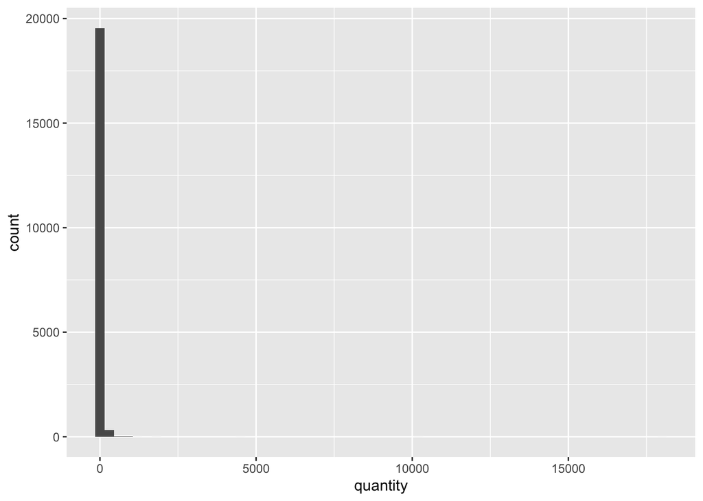

```r
library(ggplot2)
# Basic histogram
ggplot(datos, aes(x=quantity)) + geom_histogram(bins = 18000, binwidth = 300)
```

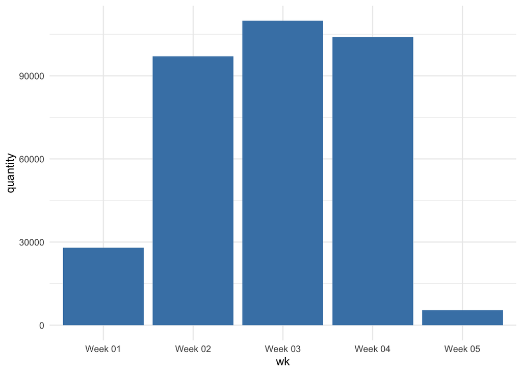

```r
p<-ggplot(data=datos, aes(x=wk, y=quantity)) +
  geom_bar(stat="identity", fill="steelblue")+
  theme_minimal()
p
```

Ahora vamos a buscar si existen na o datos perdidos

```r
sum(is.na(datos))
```

```
## [1] 15
```

Como si existen entonces procedo a eliminar los datos nulos

```r
datos <- na.omit(datos)
```